# Compositional Analysis

Augustus Pendleton

11 November, 2025

# Load packages

```r
# Efficiently load packages
pacman::p_load(phyloseq, ggpubr, vegan, tidyverse, microViz, patchwork, ggrepel, combinat, ggdendro, GUniFrac, install = FALSE)

packageDescription("GUniFrac") # Make sure we're using the version from MarschmiLab!!!!
```

[output not shown]

```r
knitr::write_bib(file = "data/08_compositional_exports/packages.bib")

# load in functions and color preferences
source("code/R/plotting_aesthetics.R")
```

# Load Data

```r
load("data/07_biodiversity_exports/full_diversity_physeq.RData")
```

This physeq already has unnecessary replicates removed, and samples merged, as described in 07_Biodiversity Analysis.

```r
merge_raremax <- min(sample_sums(full_diversity_physeq)) # Find new limit for rarefaction
```

# Transforming counts to absolute abundance

Next, we are going to normalize each of our samples by their absolute cell abundance, by multiplying the relative abundance of each read in that sample by the cells/ml of that sample.

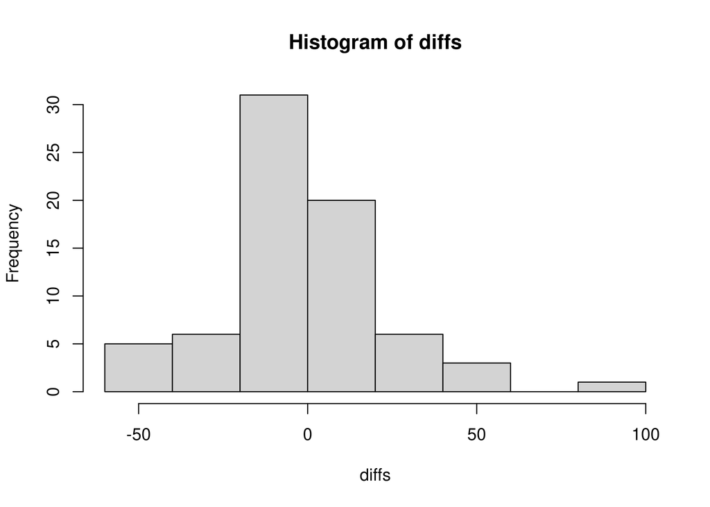

```r
rel_abund_count_matrix <- full_diversity_physeq %>%
  transform_sample_counts(function(x) {x/sum(x)}) %>% # Convert to relative abundance
  otu_table() %>% # Pull OTU table
  as.matrix() # Convert to matrix

# Pull our cell counts and arrange to match row order of OTU table
cell_counts <- full_diversity_physeq %>%
  sample_data() %>%
  data.frame() %>%
  select(Rep_ID, avg_cells_per_ml) %>%
  arrange(match(Rep_ID, row.names(rel_abund_count_matrix)))

# NO NEWS IS GOOD NEWS
stopifnot(all(cell_counts$Rep_ID == row.names(rel_abund_count_matrix)))

# Multiply relative abundance by cells/mL
transformed_asv_counts <- cell_counts$avg_cells_per_ml * rel_abund_count_matrix

# Round to integer values
trans_data_mat <- round(transformed_asv_counts@.Data,0)

diffs <- rowSums(trans_data_mat) - cell_counts$avg_cells_per_ml

hist(diffs)
```

Here, I’m looking at at how many cells I’ve “lost” or “gained” through rounding issues. This isn’t necessarily trivial. For instance, if I want to make sure every single ASV remains in my dataset, I would use ceiling, which will round up. But then samples with higher richness “gain” abundances more than less-rich samples. In the end, I decided to use round, which while imperfect (and I do remove some rare ASVs from the dataset in this way), gives the most even distribution of cell count differences (centered around zero) than other methods.

```r
full_abs_physeq <- full_diversity_physeq

full_abs_physeq@otu_table <- otu_table(trans_data_mat, taxa_are_rows = FALSE)


#Confirm we have new sample sums in the millions (cells/mL)
head(sample_sums(full_abs_physeq), 10)
```

```
## May_12_B May_12_E May_12_M May_17_E May_29_B May_29_E May_29_M May_33_B May_33_E May_33_M
##  2058850  4696825  4808348  3738732  2153099  3124901  2566158  2293159  5480867  3114432
```

```r
# Add new upwelling variable

full_abs_physeq <- full_abs_physeq %>%
  ps_mutate(Upwelling = case_when(
    Rep_ID %in% c("September_38_E","September_38_B", "September_35_E", "September_35_M", "September_35_B", "September_717_M",
                  "May_29_M", "May_29_E", "May_48_B", "May_43_E", "May_29_B") ~ "Upwelling",
    Rep_ID %in% c("May_17_E", "September_17_E", "September_17_B") ~ "Welland Canal",
    Rep_ID %in% c("May_66_E","May_35_M","May_38_M","May_35_E","May_38_E","May_717_E") ~ "Downwelling",
    TRUE ~ "Other")
  )
```

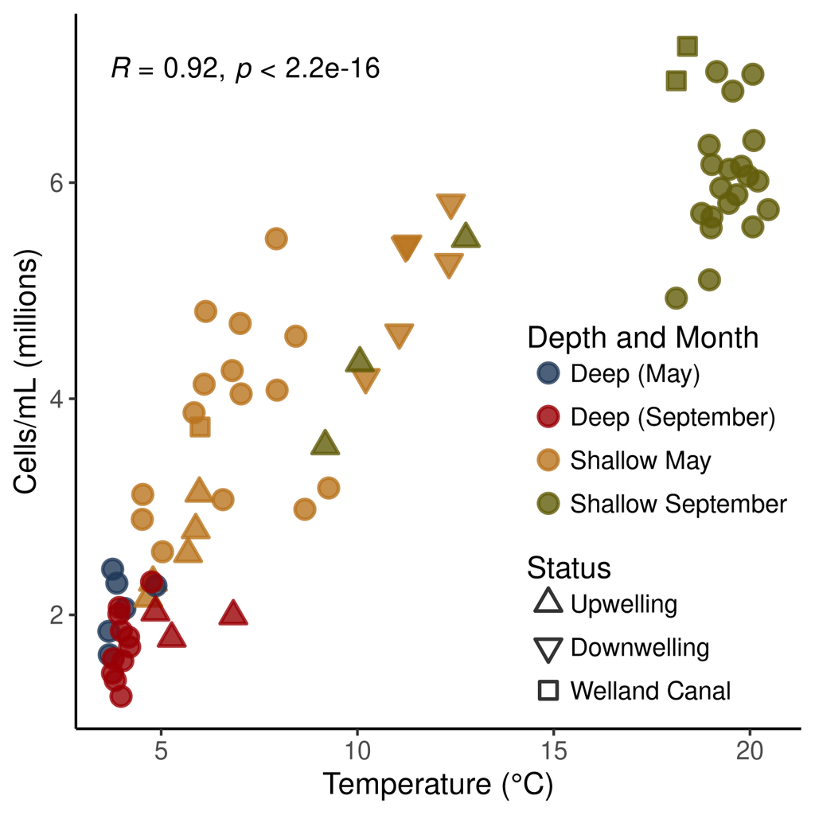

```r
full_abs_physeq %>%
  sample_data() %>%
  data.frame() %>%
  ggplot(aes(x = temperature, y = avg_cells_per_ml/1e6)) +
  geom_point(size = 3, alpha = 0.8, stroke = 1,
             aes(
    color = Comp_Group_Hier_Colors,
    fill = Comp_Group_Hier_Colors,
    shape = Upwelling)) +
  scale_color_manual(values = comp_group_colors_hier,
                   labels = c("Deep (May)",
                                "Deep (September)",
                                "Shallow May",
                                "Shallow September"),
                     name = "Depth and Month") +
  scale_fill_manual(values = comp_group_colors_hier, guide = "none") +
  scale_shape_manual(values = upwelling_shapes,
                     name = "Status",
                     breaks = c("Upwelling", "Downwelling", "Welland Canal")) +
  guides(shape = guide_legend(order = 2),
         color = guide_legend(order = 1)) +
  labs(x = "Temperature (°C)", y = "Cells/mL (millions)") +
  theme(legend.justification.inside = c(1,0.01),
        legend.position = "inside",
        legend.spacing = unit(0,"cm"),
        #legend.margin = unit(0.02,"cm"),
        legend.key.spacing = unit(0,"cm"),
        legend.box.background = element_blank()) +
  ggpubr::stat_cor(method = "spearman")
```

```r
diversity_df <- full_abs_physeq %>%
  sample_data() %>%
  data.frame()

comparisons <- combn(1:4, 2, simplify = FALSE)[c(1,2,5,6)]

# Testing differences
range(diversity_df$avg_cells_per_ml)
```

```
## [1] 1246414 7261861
```

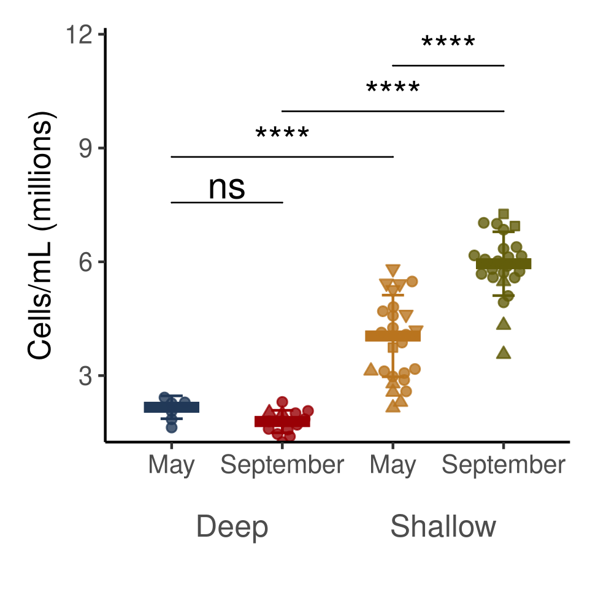

```r
base_plot <- diversity_df %>%
  ggplot(aes(x = str_replace(Comp_Group_Hier_Colors, "_", "\n"), y = avg_cells_per_ml/1e6, color = Comp_Group_Hier_Colors, fill = Comp_Group_Hier_Colors)) +
  stat_summary(geom = "errorbar", fun.min = median, fun.max = median, width = 0.5, linewidth = 2) +
  stat_summary(geom ="errorbar",
               fun.min = \(x)median(x)-sd(x),
               fun.max = \(x)median(x) + sd(x),
               width = 0.2) +
  ggbeeswarm::geom_beeswarm(alpha = 0.8, cex = 3, aes(shape = Upwelling)) +
  scale_color_manual(values = comp_group_colors_hier, guide = "none") +
  scale_fill_manual(values = comp_group_colors_hier, guide = "none") +
   scale_shape_manual(values = upwelling_shapes,
                     breaks = c("Upwelling", "Downwelling", "Welland Canal")) +
  scale_y_continuous(expand = expansion(mult = c(0,.1)), labels = scales::label_comma()) +
  scale_x_discrete(labels = c("May","September","May","September")) +
  labs(y = "Cells/mL (millions)") +
  theme(axis.title.x = element_blank(),
        strip.text = element_text(size = 12),
        legend.position = "none") +
  stat_compare_means(comparisons = comparisons, label = "p.signif", size = 5, tip.length = 0, step.increase = .2)

label_plots <- ggplot() + scale_x_continuous(limits = c(0.5, 4.5), breaks = c(1.5, 3.5), labels = c("Deep","Shallow"), position = "top") +
  theme(axis.line = element_blank(),
        axis.ticks = element_blank(),
        axis.text = element_text(size = 12))

cell_box_plots <- base_plot / ( label_plots) +
  plot_layout(heights = c(20,1))

cell_box_plots
```

# Calculate Distance Matrix

The authors compared many distance matrices (if you’re interested, feel free to contact us), but we settled on Generalized Unifrac (alpha = 0.5) using absolute abundances for most of our comparisons. This relies on a customized GUniFrac function, so make sure to install from the MarschmiLab source, rather than CRAN.

```r
# Distance object derived from absolute abundances - need to use modified GUniFrac to do so!

# absolute_wunifrac <- GUniFrac(otu.tab = as.matrix(otu_table(full_abs_physeq)), tree = phy_tree(full_diversity_physeq), alpha = c(0,0.5,1), normalize_counts = FALSE)
#
# save(absolute_wunifrac, file = "data/08_compositional_exports/absolute_wunifrac.RData")

load("data/08_compositional_exports/absolute_wunifrac.RData")
abs_unifrac_dist_0.5 <- as.dist(absolute_wunifrac$unifracs[, , "d_0.5"])
```

# Hierarchical clustering to define groups

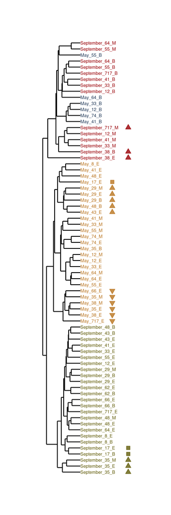

```r
wun_hclust <- abs_unifrac_dist_0.5 %>%
  hclust(method = "average")

dendrogram <- wun_hclust %>%
  as.dendrogram()

# These next four lines switch two branches, purely for aesthetic reasons
den_copy <- dendrogram
den_copy[[1]] <- dendrogram[[2]]
den_copy[[2]] <- dendrogram[[1]]
dendrogram <- den_copy

tip_annotation_df <-
  full_abs_physeq %>%
  sample_data() %>%
  data.frame() %>%
  select(Comp_Group_Hier_Colors, Rep_ID, Upwelling)

tip_groups <- data.frame(Rep_ID = dendro_data(dendrogram)$labels$label) %>%
   left_join(tip_annotation_df)

dend_data <- dendro_data(dendrogram)

ggplot(dend_data$segments) +
  geom_segment(aes(x = x, y = y, xend = xend, yend = yend)) +
  geom_text(data = dend_data$labels, aes(x, y, label = label, color = tip_groups$Comp_Group_Hier_Colors),
            hjust = 0, size = 2) +
    geom_point(data = dend_data$labels, aes(x, y = ifelse(tip_groups$Comp_Group_Hier_Colors == "Shallow_May", -0.5, -0.75), color = tip_groups$Comp_Group_Hier_Colors,fill = tip_groups$Comp_Group_Hier_Colors,  shape = tip_groups$Upwelling, alpha = tip_groups$Upwelling), size = 2) +
  theme_void() +
  coord_flip() +
  scale_y_reverse(expand = expansion(mult = .5)) +
  scale_x_continuous(expand = expansion(mult = 0.1))+
  scale_color_manual(values = comp_group_colors_hier) +
  scale_fill_manual(values = comp_group_colors_hier) +
  scale_shape_manual(values = upwelling_shapes) +
  scale_alpha_manual(values = c(0.8,0,0.8,0.8)) +
  theme(legend.position = "none")
```

We’ll also make a “blank” dendrogram that will be used to structure the compositional plot (Figure 2D)

```r
dendro_metadata <- full_diversity_physeq %>%
  sample_data() %>%
  data.frame() %>%
  select(Rep_ID, Comp_Group_Hier, Comp_Group_Hier_Colors)

dend_data_df <- dend_data$labels %>%
  dplyr::rename(Rep_ID = label) %>%
  left_join(dendro_metadata)


dendro_plot_for_barplots <- ggplot(dend_data$segments) +
  geom_segment(aes(x = y, y = x, xend = yend, yend = xend)) +
  geom_point(data = dend_data_df, aes(y, x, color = Comp_Group_Hier),
             pch = 15, size = 3) +
  theme_void()+
  scale_y_continuous(expand = expansion(mult = 0.01)) +
  scale_x_reverse(expand = expansion(mult = 0.02))+
  scale_color_manual(values = comp_three_colors, "Depth and Month") +
  theme(legend.position = "none")
```

Let’s define new comparative groups using this hierarchical tree

```r
cut_results <- wun_hclust %>%
  cutree(dendrogram, k = 3)

comp_cutresults <- case_match(cut_results, 1 ~ "Deep", 2 ~ "Shallow_May", 3 ~ "Shallow_September")

cut_table <- tibble(
  Rep_ID = names(cut_results),
  Comp_Group_Hier = comp_cutresults
) %>%
  mutate(Comp_Group_Hier_Colors = case_when(Comp_Group_Hier=="Deep"&str_detect(Rep_ID, "May") ~ "Deep (May)",
                                            Comp_Group_Hier=="Deep"&str_detect(Rep_ID, "September") ~ "Deep (September)",
                                            TRUE ~ Comp_Group_Hier))

save(cut_table, file = "data/08_compositional_exports/cut_table.RData")
```

By the time you’ll read this…these comp groups will already be in our metadata dataframe (very meta, I know).